```python
import pandas as pd
from sklearn.model_selection import train_test_split
from sklearn.preprocessing import StandardScaler, OneHotEncoder, OrdinalEncoder
from sklearn.compose import ColumnTransformer
from sklearn.pipeline import Pipeline
import torch
import torch.nn as nn
import numpy as np
import shap

from sklearn.metrics import accuracy_score, roc_auc_score, f1_score, ConfusionMatrixDisplay
import matplotlib.pyplot as plt
import dalex as dx
import seaborn as sns
```

# Neural Network

## Data preprocessing

```python
data = pd.read_csv("dataset_refining/german_credit_data_with_risk.csv")
data = data.fillna(0)
data["credit_risk"] = data["credit_risk"].map({1: 1, 2: 0})

pd.set_option('future.no_silent_downcasting', True)
data["Checking account"] = data["Checking account"].replace({"little": 1, "moderate": 2, "rich": 3}).astype(int)
data["Saving accounts"]  = data["Saving accounts"].replace({"little": 1, "moderate": 2, "quite rich": 3, "rich": 4}).astype(int)
data["Housing"]          = data["Housing"].replace({"free": 0, "rent": 1, "own": 2}).astype(int)

purpose_map = {
    "radio/TV": 0,
    "car": 0,
    "vacation/others": 0,
    "furniture/equipment": 1,
    "repairs": 1,
    "domestic appliances": 1,
    "education": 2,
    "business": 2
}

data["Purpose"] = data["Purpose"].map(purpose_map).astype(int)

X = data.drop(columns=["credit_risk"])
y = data["credit_risk"]

X_train, X_test, y_train, y_test = train_test_split(
    X, y, test_size=0.2, random_state=42, stratify=y
)

# --- Column groups ---
numeric_cols = ["Age", "Credit amount", "Duration"]

# Ordinal: order matters, so we keep ordinal encoding
ordinal_cols   = ["Checking account", "Saving accounts", "Housing", "Purpose", "Job"]

# --- Preprocessor ---
preprocessor = ColumnTransformer(transformers=[
    ("num", StandardScaler(), numeric_cols + ordinal_cols),
], remainder="drop")

X_train_proc = preprocessor.fit_transform(X_train)
X_test_proc  = preprocessor.transform(X_test)

feature_names_out  = numeric_cols + ordinal_cols

print(f"Train shape: {X_train_proc.shape}")
print(f"Feature names: {feature_names_out}")
```

```
Train shape: (800, 8)
Feature names: ['Age', 'Credit amount', 'Duration', 'Checking account', 'Saving accounts', 'Housing', 'Purpose', 'Job']
```

## Training

```python
class MLP(nn.Module):
    def __init__(self, input_dim):
        super().__init__()
        self.model = nn.Sequential(
            nn.Linear(input_dim, 64),
            nn.ReLU(),

            nn.Linear(64, 32),
            nn.ReLU(),

            nn.Linear(32, 1),
            nn.Sigmoid()
        )

    def forward(self, x):
        return self.model(x)
```

```python
torch.manual_seed(42)
torch.cuda.manual_seed_all(42)
np.random.seed(42)
torch.backends.cudnn.deterministic = True
torch.backends.cudnn.benchmark = False
```

```python
# Convert to tensors
X_train_t = torch.tensor(X_train_proc, dtype=torch.float32)
X_test_t  = torch.tensor(X_test_proc,  dtype=torch.float32)
y_train_t = torch.tensor(y_train.values, dtype=torch.float32).unsqueeze(1)
y_test_t  = torch.tensor(y_test.values,  dtype=torch.float32).unsqueeze(1)

model     = MLP(input_dim=X_train_t.shape[1])
criterion = nn.BCELoss()
optimizer = torch.optim.Adam(model.parameters(), lr=0.001)

history = {"train_loss": [], "test_loss": [],
           "train_acc":  [], "test_acc":  [],
           "train_f1":   [], "test_f1":   [],
           "train_auc":  [], "test_auc":  []}

epochs = 200
for epoch in range(epochs):
    # --- Train ---
    model.train()
    outputs = model(X_train_t)
    loss    = criterion(outputs, y_train_t)
    optimizer.zero_grad()
    loss.backward()
    optimizer.step()

    # --- Eval (no gradients needed) ---
    model.eval()
    with torch.no_grad():
        train_proba = model(X_train_t).numpy().flatten()
        test_proba  = model(X_test_t).numpy().flatten()

    train_pred = (train_proba >= 0.5).astype(int)
    test_pred  = (test_proba  >= 0.5).astype(int)
    y_tr = y_train.values
    y_te = y_test.values

    train_loss = criterion(torch.tensor(train_proba).unsqueeze(1), y_train_t).item()
    test_loss  = criterion(torch.tensor(test_proba).unsqueeze(1),  y_test_t).item()

    history["train_loss"].append(train_loss)
    history["test_loss"].append(test_loss)
    history["train_acc"].append(accuracy_score(y_tr, train_pred))
    history["test_acc"].append(accuracy_score(y_te, test_pred))
    history["train_auc"].append(roc_auc_score(y_tr, train_proba))
    history["test_auc"].append(roc_auc_score(y_te, test_proba))
    history["train_f1"].append(f1_score(y_tr, train_pred))
    history["test_f1"].append(f1_score(y_te, test_pred))

    if epoch % 5 == 0:
        print(f"Epoch {epoch:>3} | "
              f"Loss: {train_loss:.4f}/{test_loss:.4f} | "
              f"Acc: {history['train_acc'][-1]:.4f}/{history['test_acc'][-1]:.4f} | "
              f"F1: {history['train_f1'][-1]:.4f}/{history['test_f1'][-1]:.4f} | "
              f"AUC: {history['train_auc'][-1]:.4f}/{history['test_auc'][-1]:.4f}")
```

```
Epoch   0 | Loss: 0.7321/0.7344 | Acc: 0.3100/0.3300 | F1: 0.0383/0.0822 | AUC: 0.6202/0.6436
Epoch   5 | Loss: 0.7004/0.7004 | Acc: 0.4562/0.4450 | F1: 0.4373/0.4188 | AUC: 0.6068/0.6339
Epoch  10 | Loss: 0.6774/0.6767 | Acc: 0.6062/0.6000 | F1: 0.6909/0.6875 | AUC: 0.5951/0.5964
Epoch  15 | Loss: 0.6595/0.6587 | Acc: 0.6663/0.6800 | F1: 0.7766/0.7867 | AUC: 0.5907/0.5825
Epoch  20 | Loss: 0.6433/0.6429 | Acc: 0.6975/0.6700 | F1: 0.8118/0.7925 | AUC: 0.5959/0.5835
Epoch  25 | Loss: 0.6280/0.6281 | Acc: 0.6975/0.6550 | F1: 0.8178/0.7903 | AUC: 0.6086/0.5973
Epoch  30 | Loss: 0.6131/0.6142 | Acc: 0.7050/0.6750 | F1: 0.8252/0.8060 | AUC: 0.6271/0.6183
Epoch  35 | Loss: 0.5988/0.6011 | Acc: 0.7063/0.6900 | F1: 0.8261/0.8166 | AUC: 0.6505/0.6451
Epoch  40 | Loss: 0.5854/0.5889 | Acc: 0.7075/0.6900 | F1: 0.8269/0.8166 | AUC: 0.6741/0.6676
Epoch  45 | Loss: 0.5730/0.5781 | Acc: 0.7100/0.6850 | F1: 0.8276/0.8131 | AUC: 0.6941/0.6810
Epoch  50 | Loss: 0.5620/0.5693 | Acc: 0.7063/0.6900 | F1: 0.8237/0.8144 | AUC: 0.7079/0.6893
Epoch  55 | Loss: 0.5529/0.5632 | Acc: 0.7163/0.6900 | F1: 0.8263/0.8098 | AUC: 0.7174/0.6927
Epoch  60 | Loss: 0.5458/0.5598 | Acc: 0.7225/0.6950 | F1: 0.8279/0.8088 | AUC: 0.7238/0.6950
Epoch  65 | Loss: 0.5404/0.5589 | Acc: 0.7238/0.6950 | F1: 0.8264/0.8039 | AUC: 0.7292/0.6958
Epoch  70 | Loss: 0.5362/0.5595 | Acc: 0.7238/0.6800 | F1: 0.8253/0.7908 | AUC: 0.7333/0.6967
Epoch  75 | Loss: 0.5328/0.5604 | Acc: 0.7288/0.6900 | F1: 0.8271/0.7961 | AUC: 0.7382/0.7017
Epoch  80 | Loss: 0.5295/0.5611 | Acc: 0.7288/0.6900 | F1: 0.8271/0.7947 | AUC: 0.7423/0.7030
Epoch  85 | Loss: 0.5263/0.5610 | Acc: 0.7300/0.6950 | F1: 0.8278/0.7987 | AUC: 0.7467/0.7057
Epoch  90 | Loss: 0.5230/0.5601 | Acc: 0.7325/0.7000 | F1: 0.8293/0.8026 | AUC: 0.7509/0.7070
Epoch  95 | Loss: 0.5197/0.5585 | Acc: 0.7325/0.7000 | F1: 0.8291/0.8026 | AUC: 0.7554/0.7100
Epoch 100 | Loss: 0.5163/0.5566 | Acc: 0.7362/0.7100 | F1: 0.8311/0.8092 | AUC: 0.7606/0.7135
Epoch 105 | Loss: 0.5129/0.5547 | Acc: 0.7388/0.7150 | F1: 0.8321/0.8119 | AUC: 0.7650/0.7165
Epoch 110 | Loss: 0.5094/0.5531 | Acc: 0.7375/0.7150 | F1: 0.8309/0.8119 | AUC: 0.7697/0.7186
Epoch 115 | Loss: 0.5057/0.5517 | Acc: 0.7450/0.7100 | F1: 0.8352/0.8067 | AUC: 0.7743/0.7227
Epoch 120 | Loss: 0.5020/0.5504 | Acc: 0.7512/0.7100 | F1: 0.8394/0.8067 | AUC: 0.7791/0.7258
Epoch 125 | Loss: 0.4983/0.5492 | Acc: 0.7525/0.7000 | F1: 0.8398/0.7987 | AUC: 0.7834/0.7294
Epoch 130 | Loss: 0.4945/0.5482 | Acc: 0.7550/0.7000 | F1: 0.8412/0.7987 | AUC: 0.7879/0.7327
Epoch 135 | Loss: 0.4906/0.5469 | Acc: 0.7562/0.7100 | F1: 0.8424/0.8054 | AUC: 0.7922/0.7362
Epoch 140 | Loss: 0.4866/0.5452 | Acc: 0.7600/0.7150 | F1: 0.8447/0.8081 | AUC: 0.7968/0.7389
Epoch 145 | Loss: 0.4826/0.5435 | Acc: 0.7600/0.7150 | F1: 0.8444/0.8081 | AUC: 0.8014/0.7425
Epoch 150 | Loss: 0.4787/0.5417 | Acc: 0.7638/0.7200 | F1: 0.8465/0.8108 | AUC: 0.8054/0.7450
Epoch 155 | Loss: 0.4748/0.5400 | Acc: 0.7662/0.7200 | F1: 0.8476/0.8108 | AUC: 0.8097/0.7481
Epoch 160 | Loss: 0.4708/0.5383 | Acc: 0.7688/0.7200 | F1: 0.8490/0.8108 | AUC: 0.8138/0.7512
Epoch 165 | Loss: 0.4669/0.5368 | Acc: 0.7738/0.7350 | F1: 0.8518/0.8203 | AUC: 0.8180/0.7530
Epoch 170 | Loss: 0.4631/0.5356 | Acc: 0.7738/0.7400 | F1: 0.8515/0.8231 | AUC: 0.8221/0.7540
Epoch 175 | Loss: 0.4593/0.5346 | Acc: 0.7738/0.7400 | F1: 0.8513/0.8231 | AUC: 0.8255/0.7552
Epoch 180 | Loss: 0.4555/0.5333 | Acc: 0.7825/0.7450 | F1: 0.8564/0.8259 | AUC: 0.8292/0.7567
Epoch 185 | Loss: 0.4518/0.5321 | Acc: 0.7863/0.7450 | F1: 0.8581/0.8259 | AUC: 0.8329/0.7589
Epoch 190 | Loss: 0.4481/0.5311 | Acc: 0.7900/0.7400 | F1: 0.8600/0.8207 | AUC: 0.8367/0.7630
Epoch 195 | Loss: 0.4445/0.5306 | Acc: 0.7887/0.7450 | F1: 0.8590/0.8247 | AUC: 0.8399/0.7640
```

## Global Results

```python
print("=" * 40)
print(f"  Accuracy : {history["test_acc"][-1]:.4f}")
print(f"  F1 Score : {history["test_f1"][-1]:.4f}")
print(f"  AUC      : {history["test_auc"][-1]:.4f}")
print("=" * 40)
```

```
========================================
  Accuracy : 0.7550
  F1 Score : 0.8316
  AUC      : 0.7650
========================================
```

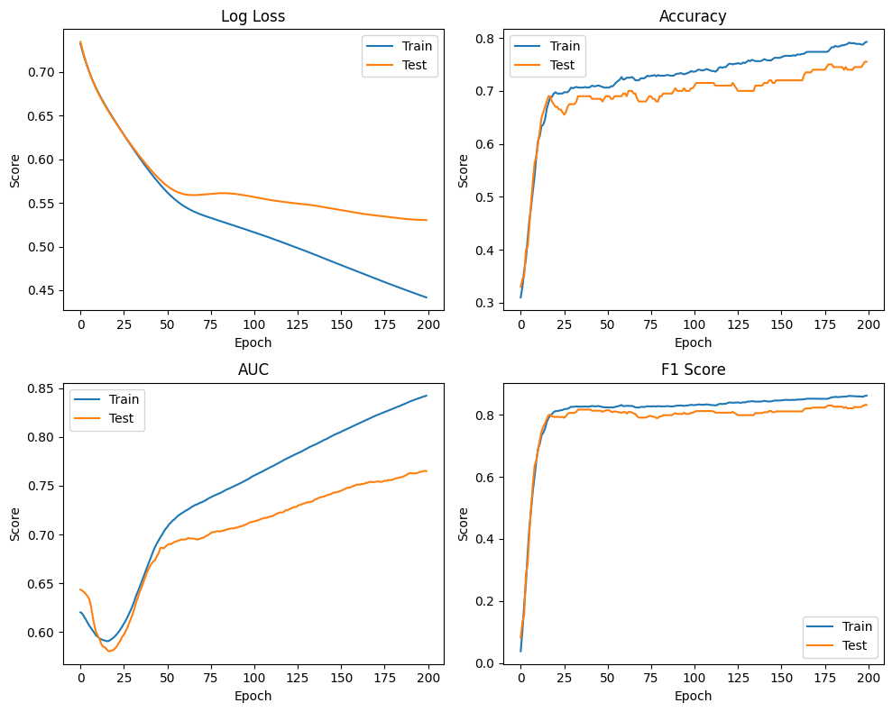

```python
fig, axs = plt.subplots(2, 2, figsize=(10, 8))

# --- Loss ---
axs[0, 0].plot(history["train_loss"], label="Train")
axs[0, 0].plot(history["test_loss"],  label="Test")
axs[0, 0].set_title("Log Loss")
axs[0, 0].legend()

# --- Accuracy ---
axs[0, 1].plot(history["train_acc"], label="Train")
axs[0, 1].plot(history["test_acc"],  label="Test")
axs[0, 1].set_title("Accuracy")
axs[0, 1].legend()

# --- AUC ---
axs[1, 0].plot(history["train_auc"], label="Train")
axs[1, 0].plot(history["test_auc"],  label="Test")
axs[1, 0].set_title("AUC")
axs[1, 0].legend()

# --- F1 ---
axs[1, 1].plot(history["train_f1"], label="Train")
axs[1, 1].plot(history["test_f1"],  label="Test")
axs[1, 1].set_title("F1 Score")
axs[1, 1].legend()

for ax in axs.flat:
    ax.set_xlabel("Epoch")
    ax.set_ylabel("Score")

plt.tight_layout()
plt.show()
```

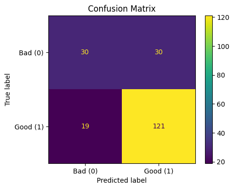

```python
model.eval()
with torch.no_grad():
    test_proba = model(X_test_t).numpy().flatten()

y_pred  = (test_proba >= 0.5).astype(int)
y_proba = test_proba

fig, ax = plt.subplots(figsize=(5, 4))
ConfusionMatrixDisplay.from_predictions(
    y_te, y_pred, display_labels=["Bad (0)", "Good (1)"], ax=ax
)
ax.set_title("Confusion Matrix")
plt.tight_layout()
plt.show()
```

The confusion matrix shows that the model correctly predicts most 'Good' cases (121/140) but struggles with 'Bad' cases (30/60), misclassifying 30 bad credits as good. The model remains biased toward the majority class, which is a direct consequence of the class imbalance in the dataset.

```python
explainer = shap.GradientExplainer(model, X_train_t)
shap_values = explainer.shap_values(X_test_t)
shap_values_2d = shap_values[0].squeeze(-1) if isinstance(shap_values, list) else shap_values.squeeze(-1)
```

```python
plt.figure()
shap.summary_plot(shap_values_2d, X_test_t.numpy(), feature_names=feature_names_out, plot_size=(10, 6), show=False, rng=42)
plt.title("SHAP Summary Plot")
plt.tight_layout()
plt.show()
```

[output not shown]

- **Checking account** - same as in XGBoost, a value of `0` (no recorded checking account) contributes positively to good credit risk-likely reflecting individuals who maintain accounts in other banks or have alternative financial arrangements. Small or moderate balances are associated with higher risk, while high balances slightly increase predicted safety.
- **Duration** - There is a clear trend with longer duraction leading to higher risk (low shap values), the classes are pretty well separated (not perfect though).
- **Credit amount** - values are not so well separated, but high values have a very clear negative impact (the most significant across all criterions) while moderately low values a positive impact. Low values are around 0 likely because for someone with low credit, it is more likely that this low credit is all he can get.
- **Saving Accounts** - here `0` reffers to no saving account and it correlates positively with good risk maybe because those people invest their money outside banks and it serves them better, on the other hand people with rich saving accounts also score well which is obvious. Most people have little money on saving accounts and the model penalizes it slightly
- **Housing** - Owners get a small positive value, and non-owners get a penalty.
- **Age** - Generally higher = better, with experience people generally advance their careers, build their own capital and have greater stability in life
- **Purpose** - Here high and middle values reffer to ambitious and necessary purposes like school are repairs, it may be that people who take these loans are in a bad position in their life which correlates with bad risk, people who take their loans recklessly for cars and holidays are often in a more stable position
- **Job** - Generally better job is better (lower) credit risk

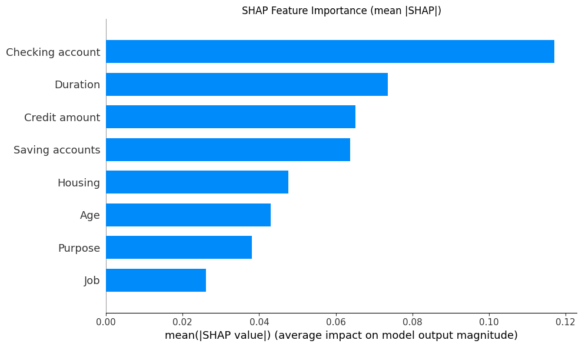

```python
plt.figure()
shap.summary_plot(shap_values_2d, X_test_t.numpy(), feature_names=feature_names_out, plot_size=(10, 6), plot_type="bar", show=False, rng=42)
plt.title("SHAP Feature Importance (mean |SHAP|)")
plt.tight_layout()
plt.show()
```

The SHAP feature importance shows that `Checking account` is by far the most influential feature, significantly exceeding all others. It is followed by `Duration`, `Credit amount` and `Saving accounts`, indicating that the model relies primarily on financial attributes. `Housing`, `Age` and `Purpose` have moderate importance, and lastly`Job` contributes the least to the model's predictions.

## Sample Analysis

```python
def plot_shap_waterfall_nn(explainer, sample_proc, feature_names, X_test_t):
    tensor = torch.tensor(sample_proc, dtype=torch.float32)
    sv = explainer.shap_values(tensor)
    if isinstance(sv, list):
        sv = sv[0]
    sv = np.array(sv).squeeze()  # force to 1D (n_features,)

    model.eval()
    with torch.no_grad():
        base = model(X_test_t).squeeze().mean().item()

    shap.plots._waterfall.waterfall_legacy(
        base, sv,
        feature_names=feature_names,
        max_display=10
    )
    prob = predict_proba_nn(model, sample_proc)
    cls  = int(float(prob) > 0.5)
    print(f"Predicted probability (class 1): {float(prob):.4f}  →  class {cls}")
```

```python
def minimal_flip(model, X_test, idx, feature, max_steps=100, step_fraction=0.01, direction=1):
    model.eval()

    def predict_class(df_row):
        tensor = torch.tensor(df_row.values, dtype=torch.float32)
        with torch.no_grad():
            output = model(tensor)
            return int((output.squeeze() > 0.5).item())

    X_sample = X_test.iloc[[idx]].copy()
    original_class = predict_class(X_sample)

    if X_sample[feature].dtype.kind in 'iuf':
        step = step_fraction * (X_test[feature].max() - X_test[feature].min())
        if X_sample[feature].dtype.kind == 'i':
            step = max(1, round(step))
    else:
        step = 1

    sample_cf = X_sample.copy()
    for i in range(1, max_steps + 1):
        if X_sample[feature].dtype.kind in 'iuf':
            sample_cf[feature] += step * direction
        else:
            sample_cf[feature] = int(sample_cf[feature] + step * direction)

        new_class = predict_class(sample_cf)
        if new_class != original_class:
            return {
                'original_class': original_class,
                'flipped_class': new_class,
                'feature': feature,
                'total_change': step * i,
                'steps': i,
                'sample_cf': sample_cf
            }

    return {
        'original_class': original_class,
        'flipped_class': original_class,
        'feature': feature,
        'total_change': 0,
        'steps': 0,
        'sample_cf': sample_cf
    }
```

```python
model.eval()

explainer  = shap.GradientExplainer(model, X_train_t)

X_test_df  = pd.DataFrame(X_test_proc,  columns=feature_names_out)
X_train_df = pd.DataFrame(X_train_proc, columns=feature_names_out)

# precompute SHAP values for the whole test set (needed for groupby analysis)
shap_values_nn = explainer.shap_values(X_test_t).squeeze()  # shape: (n_samples, n_features)
```

### Sample selection

```python
def predict_proba_nn(model, X):
    # accepts numpy array or DataFrame
    if isinstance(X, np.ndarray):
        tensor = torch.tensor(X, dtype=torch.float32)
    else:
        tensor = torch.tensor(X.values.astype(float), dtype=torch.float32)

    model.eval()
    with torch.no_grad():
        output = model(tensor).squeeze()
    return output.numpy()

def predict_nn(model, X):
    proba = predict_proba_nn(model, X)
    return (proba > 0.5).astype(int)

probas = predict_proba_nn(model, X_test_proc)
preds  = predict_nn(model, X_test_proc)

idx_1 = 12
idx_2 = 71
idx_3 = 131
print(f"Probability {idx_1}:", probas[idx_1])
print(f"Probability {idx_2}:", probas[idx_2])
print(f"Probability {idx_3}:", probas[idx_3])
```

```
Probability 12: 0.5781058
Probability 71: 0.5063002
Probability 131: 0.53907317
```

### Sample 12

#### Analytical

```python
idx = 12
sample_proc = X_test_proc[[idx]]
sample_df = X_test_df.iloc[[idx]].copy()
```

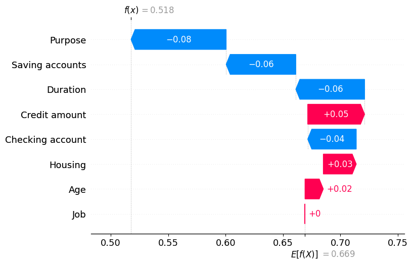

```
Predicted probability (class 1): 0.5781  →  class 1
```

```python
plot_shap_waterfall_nn(explainer, sample_proc, feature_names_out, X_test_t)
```

```python
display(sample_df)
```

|  | Age | Credit amount | Duration | Checking account | Saving accounts | Housing | Purpose | Job |
| --- | --- | --- | --- | --- | --- | --- | --- | --- |
| 12 | 0.053977 | 0.263304 | 0.508166 | 1.074861 | -0.186225 | 0.570794 | 1.977903 | 0.146418 |

```python
feature_name = "Credit amount"
feature_idx  = feature_names_out.index(feature_name)
checking_shap = shap_values_nn[:, feature_idx]

grouped = X_test_df.copy()
grouped["shap_value"] = checking_shap

# bin into 10 equal-width buckets
grouped["bin"] = pd.cut(grouped[feature_name], bins=10)
avg_by_bin = grouped.groupby("bin", observed=False)["shap_value"].mean()

print(avg_by_bin)
print(
    f"Difference in avg SHAP between 3rd and 9th bin of '{feature_name}':",
    avg_by_bin.iloc[2] - avg_by_bin.iloc[8]
)
```

```
bin
(-1.034, -0.468]   -0.012496
(-0.468, 0.0927]    0.033935
(0.0927, 0.653]     0.063442
(0.653, 1.213]      0.043781
(1.213, 1.774]     -0.042644
(1.774, 2.334]     -0.061556
(2.334, 2.895]      0.004290
(2.895, 3.455]     -0.301799
(3.455, 4.015]     -0.562003
(4.015, 4.576]     -0.539459
Name: shap_value, dtype: float64
Difference in avg SHAP between 3rd and 9th bin of 'Credit amount': 0.6254453165312333
```

Looking at the avg SHAP values differences, I have to increase `Credit amount` by ~3.2

```python
sample_df['Credit amount'] = 3.5
```

```python
predict_proba_nn(model, sample_df)
```

```
array(0.084618, dtype=float32)
```

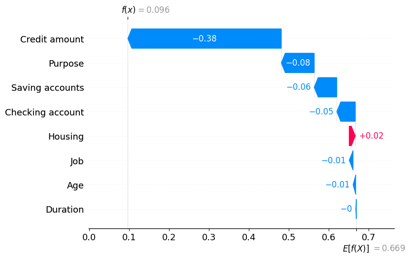

```
Predicted probability (class 1): 0.0846  →  class 0
```

```python
feature_idx_num = feature_names_out.index("Checking account")
plot_shap_waterfall_nn(explainer, sample_df.to_numpy(), feature_names_out, X_test_t)
```

#### Sampling

```python
res = minimal_flip(model, X_test_df, idx, feature='Credit amount', max_steps=100, step_fraction=0.01, direction=1)
res
```

```
{'original_class': 1,
 'flipped_class': 0,
 'feature': 'Credit amount',
 'total_change': np.float64(0.7284738089061445),
 'steps': 13,
 'sample_cf':          Age  Credit amount  Duration  Checking account  Saving accounts  \
 12  0.053977       0.991777  0.508166          1.074861        -0.186225

      Housing   Purpose       Job
 12  0.570794  1.977903  0.146418  }
```

```python
res["sample_cf"]
```

|  | Age | Credit amount | Duration | Checking account | Saving accounts | Housing | Purpose | Job |
| --- | --- | --- | --- | --- | --- | --- | --- | --- |
| 12 | 0.053977 | 0.991777 | 0.508166 | 1.074861 | -0.186225 | 0.570794 | 1.977903 | 0.146418 |

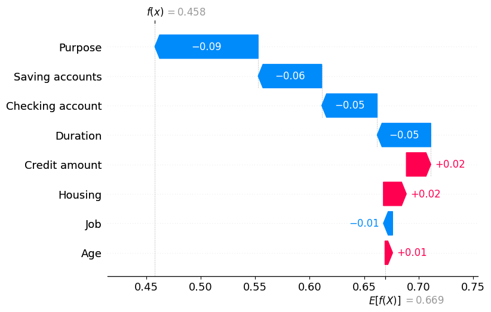

```
Predicted probability (class 1): 0.4942  →  class 0
```

```python
plot_shap_waterfall_nn(explainer, res["sample_cf"].values, feature_names_out, X_test_t)
```

The analytical estimate **3.2** was based on average SHAP values across bins of the test set, which don't reflect the specific feature interactions for this individual sample. The sampling result **0.73** is more precise because it directly probes the model's decision boundary for this exact alternative. The discrepancy highlights a key limitation of using population-averaged SHAP values for individual counterfactual reasoning.

### Sample 71

#### Analytical

```python
idx = 71
sample_proc = X_test_proc[[idx]]
sample_df = X_test_df.iloc[[idx]].copy()
```

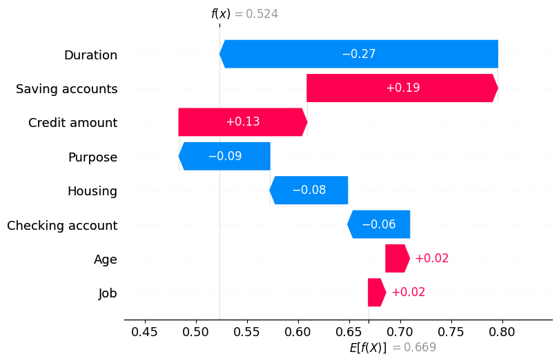

```
Predicted probability (class 1): 0.5063  →  class 1
```

```python
plot_shap_waterfall_nn(explainer, sample_proc, feature_names_out, X_test_t)
```

```python
display(sample_df)
```

|  | Age | Credit amount | Duration | Checking account | Saving accounts | Housing | Purpose | Job |
| --- | --- | --- | --- | --- | --- | --- | --- | --- |
| 71 | 0.229868 | 1.262123 | 2.237043 | 1.074861 | -1.235378 | -2.443298 | 1.977903 | 0.146418 |

`Duration` - one of the more influential attributes is taking away the most SHAP value right now, by increasing it further I will be able to move the score down. Right now we have `0.5063` extra SHAP value to be disposed of.

```python
feature_name = "Duration"
feature_idx  = feature_names_out.index(feature_name)

checking_shap = shap_values_nn[:, feature_idx]

grouped = X_test_df.copy()
grouped["shap_value"] = checking_shap
avg_by_value = grouped.groupby(feature_name)["shap_value"].mean()
print(avg_by_value)
print(
    f"Difference in avg SHAP between 4th and 18th value of '{feature_name}': {avg_by_value.iloc[19] - avg_by_value.iloc[18]:.4f}")
```

```
Duration
-1.303038    0.057718
-1.220711    0.094847
-1.138383    0.112584
-1.056056    0.149248
-0.973728    0.084656
-0.891401    0.090535
-0.809073    0.047660
-0.726746    0.074382
-0.479763    0.039551
-0.232781    0.007242
-0.068126   -0.025896
 0.014201   -0.013220
 0.261184   -0.048943
 0.508166   -0.031758
 0.755149   -0.042015
 1.002131   -0.104703
 1.249113   -0.101199
 1.496096   -0.048646
 1.990061   -0.249187
 2.237043   -0.198580
 3.224973   -0.065961
Name: shap_value, dtype: float64
Difference in avg SHAP between 4th and 18th value of 'Duration': 0.0506
```

`Duration` currently has second highest value possible and we know from SHAP summary plot that long duration is correlated with negative SHAP values and hence negative model predictions. Looking at the average SHAP values for different Durations, we see the same situation as for the previous sample where the differences are not that much significant. Yet the model is assigning only **0.5063** probability to the good risk class showing it's indecision and likely very little change will be needed to flip the class.

Looking at average values we are already quite high and there is only 1 higher value present in the dataset, I think that only a small change is required to flip the class so I will go with **2.5** which is only slightly above the current **2.24**.

```python
sample_df['Duration'] = 2.5
```

```python
predict_proba_nn(model, sample_df)
```

```
array(0.47380736, dtype=float32)
```

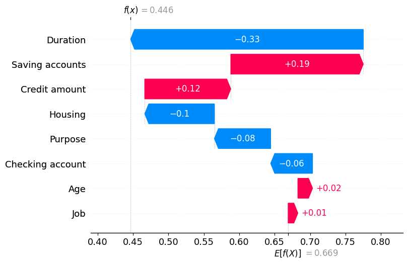

```
Predicted probability (class 1): 0.4738  →  class 0
```

```python
feature_idx_num = feature_names_out.index('Credit amount')
plot_shap_waterfall_nn(explainer, sample_df.to_numpy(), feature_names_out, X_test_t)
```

#### Sampling

```python
res = minimal_flip(model, X_test_df, idx, feature='Duration', max_steps=100, step_fraction=0.01, direction=1)
res
```

```
{'original_class': 1,
 'flipped_class': 0,
 'feature': 'Duration',
 'total_change': np.float64(0.09056021331949494),
 'steps': 2,
 'sample_cf':          Age  Credit amount  Duration  Checking account  Saving accounts  \
 71  0.229868       1.262123  2.327603          1.074861        -1.235378

      Housing   Purpose       Job
 71 -2.443298  1.977903  0.146418  }
```

```python
res["sample_cf"]
```

|  | Age | Credit amount | Duration | Checking account | Saving accounts | Housing | Purpose | Job |
| --- | --- | --- | --- | --- | --- | --- | --- | --- |
| 71 | 0.229868 | 1.262123 | 2.327603 | 1.074861 | -1.235378 | -2.443298 | 1.977903 | 0.146418 |

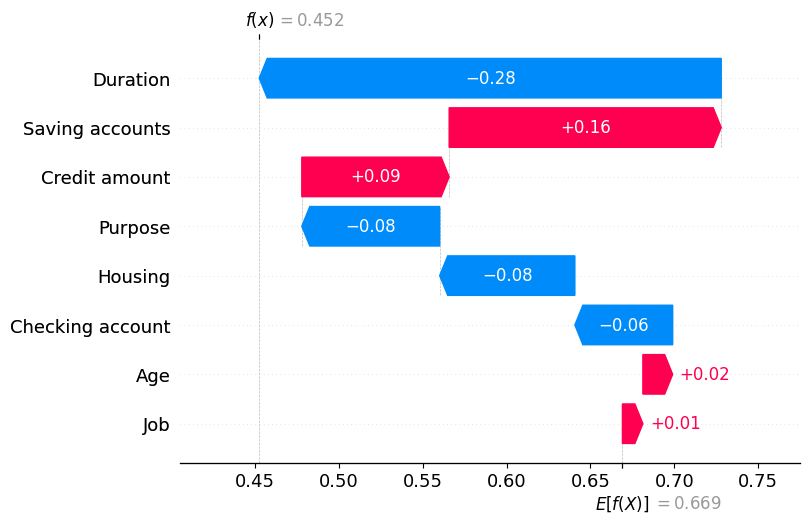

```
Predicted probability (class 1): 0.4951  →  class 0
```

```python
plot_shap_waterfall_nn(explainer, res["sample_cf"].values, feature_names_out, X_test_t)
```

The required minimal change was smaller than I anticipated **0.09 vs 0.26**, it was difficult to point to a particular point in space because of continuous space and sparse data points.

### Sample 131

#### Analytical

```python
idx = 131
sample_proc = X_test_proc[[idx]]
sample_df = X_test_df.iloc[[idx]].copy()
```

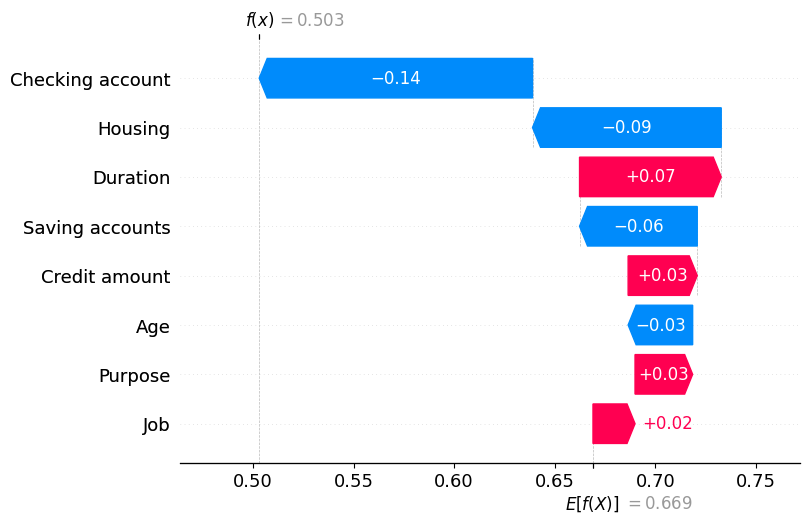

```
Predicted probability (class 1): 0.5391  →  class 1
```

```python
plot_shap_waterfall_nn(explainer, sample_proc, feature_names_out, X_test_t)
```

```python
display(sample_df)
```

|  | Age | Credit amount | Duration | Checking account | Saving accounts | Housing | Purpose | Job |
| --- | --- | --- | --- | --- | --- | --- | --- | --- |
| 131 | -0.561643 | -0.37441 | -0.726746 | 0.026216 | -0.186225 | -2.443298 | -0.708553 | 0.146418 |

```python
feature_name = "Duration"
feature_idx  = feature_names_out.index(feature_name)

checking_shap = shap_values_nn[:, feature_idx]

grouped = X_test_df.copy()
grouped["shap_value"] = checking_shap
avg_by_value = grouped.groupby(feature_name)["shap_value"].mean()
print(avg_by_value)
print(
    f"Difference in avg SHAP between 4th and 18th value of '{feature_name}': {avg_by_value.iloc[19] - avg_by_value.iloc[7]:.4f}")
```

```
Duration
-1.303038    0.057718
-1.220711    0.094847
-1.138383    0.112584
-1.056056    0.149248
-0.973728    0.084656
-0.891401    0.090535
-0.809073    0.047660
-0.726746    0.074382
-0.479763    0.039551
-0.232781    0.007242
-0.068126   -0.025896
 0.014201   -0.013220
 0.261184   -0.048943
 0.508166   -0.031758
 0.755149   -0.042015
 1.002131   -0.104703
 1.249113   -0.101199
 1.496096   -0.048646
 1.990061   -0.249187
 2.237043   -0.198580
 3.224973   -0.065961
Name: shap_value, dtype: float64
Difference in avg SHAP between 4th and 18th value of 'Duration': -0.2730
```

Average SHAP value contribution tells me that modifying `Duration` in the [-1;1] range makes a consistent difference, and given how much impact this variable had in the last sample, I will increase it by 0.32 so the new value is **-0.4**

```python
sample_df['Duration'] = -0.4
```

```python
predict_proba_nn(model, sample_df)
```

```
array(0.47466305, dtype=float32)
```

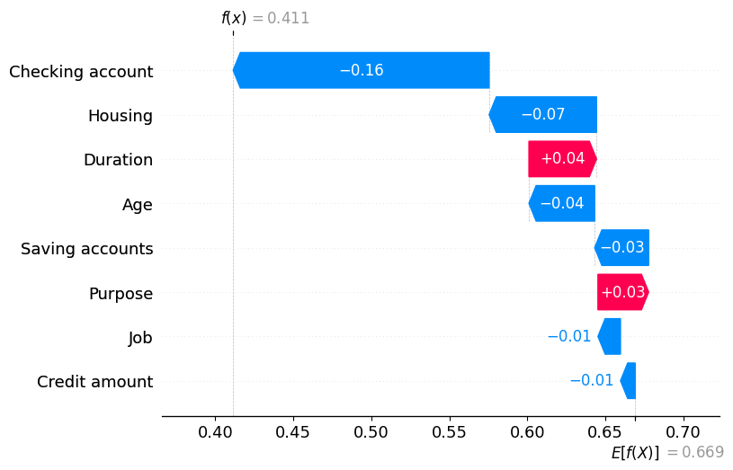

```
Predicted probability (class 1): 0.4747  →  class 0
```

```python
feature_idx_num = feature_names_out.index('Credit amount')
plot_shap_waterfall_nn(explainer, sample_df.to_numpy(), feature_names_out, X_test_t)
```

#### Sampling

```python
res = minimal_flip(model, X_test_df, idx, feature='Duration', max_steps=100, step_fraction=0.01, direction=1)
res
```

```
{'original_class': 1,
 'flipped_class': 0,
 'feature': 'Duration',
 'total_change': np.float64(0.1811204266389899),
 'steps': 4,
 'sample_cf':           Age  Credit amount  Duration  Checking account  Saving accounts  \
 131 -0.561643       -0.37441 -0.545625          0.026216        -0.186225

       Housing   Purpose       Job
 131 -2.443298 -0.708553  0.146418  }
```

```python
res["sample_cf"]
```

|  | Age | Credit amount | Duration | Checking account | Saving accounts | Housing | Purpose | Job |
| --- | --- | --- | --- | --- | --- | --- | --- | --- |
| 131 | -0.561643 | -0.37441 | -0.545625 | 0.026216 | -0.186225 | -2.443298 | -0.708553 | 0.146418 |

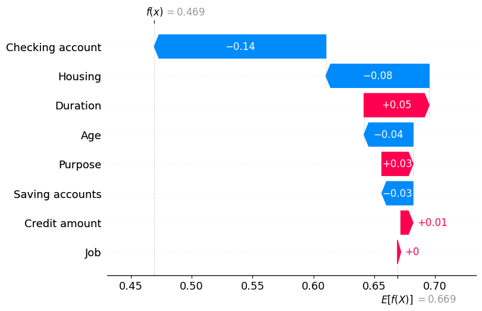

```
Predicted probability (class 1): 0.4997  →  class 0
```

```python
plot_shap_waterfall_nn(explainer, res["sample_cf"].values, feature_names_out, X_test_t)
```

The required minimal change was smaller than I anticipated **0.18 vs 0.32**, I close but not lucky enough to get the exact value.

## Interpretation of the model

```python
def predict_fn(*args, **kwargs):
    X = args[-1]

    X_scaled = preprocessor.transform(X)
    X_tensor = torch.tensor(X_scaled, dtype=torch.float32)

    model.eval()
    with torch.no_grad():
        preds = model(X_tensor).cpu().numpy().reshape(-1)

    return preds

explainer_dalex = dx.Explainer(
    model,
    X_test.drop(columns=["Sex"]),
    y_test,
    predict_function=predict_fn,
    label="Neural Network"
)
```

```
Preparation of a new explainer is initiated

  -> data              : 200 rows 8 cols
  -> target variable   : Parameter 'y' was a pandas.Series. Converted to a numpy.ndarray.
  -> target variable   : 200 values
  -> model_class       : __main__.MLP (default)
  -> label             : Neural Network
  -> predict function  : <function predict_fn at 0x7fdcc483e980> will be used
  -> predict function  : Accepts only pandas.DataFrame, numpy.ndarray causes problems.
  -> predicted values  : min = 0.0599, mean = 0.669, max = 0.987
  -> model type        : 'model_type' not provided and cannot be extracted.
  -> model type        : Some functionalities won't be available.
  -> residual function : difference between y and yhat (default)
  -> residuals         : min = -0.952, mean = 0.031, max = 0.902
  -> model_info        : package __main__

A new explainer has been created!
```

### Q1

Based on the parameters obtained, can we say something about the user’s preferences?

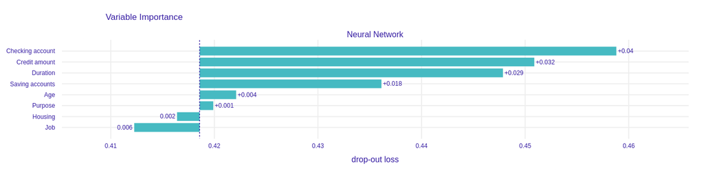

```python
vi = explainer_dalex.model_parts()
vi.plot()
```

```python
plt.figure()
shap.summary_plot(shap_values_2d, X_test_t.numpy(), feature_names=feature_names_out, plot_size=(10, 6), show=False, rng=42)
plt.title("SHAP Summary Plot")
plt.tight_layout()
plt.show()
```

[output not shown]

The neural network reveals a clear preference structure driven by a small subset of criteria. The most influential features are `Checking account`, `Credit amount`, `Duration`, and `Saving accounts`, indicating that liquidity and debt burden are the primary drivers of creditworthiness assessment. This suggests that the decision-maker exhibits a risk-averse, financially conservative preference structure, prioritizing short-term, low-value credit commitments backed by strong account liquidity. `Purpose`, `Housing`, `Age`, and `Job` show negligible importance, with `Housing` and `Job` producing slightly negative dropout loss in permutation importance - a statistical artifact of near-zero effect rather than a meaningful result, consistent with the small test set size of 200 samples. These criteria play no meaningful role in the model's decisions and could potentially be removed without significantly affecting performance.

Since the neural network parameters (weights and biases) are not directly interpretable, all preference inference relies entirely on post-hoc attribution methods such as permutation importance and SHAP. Within this limitation, the model reflects a conservative decision policy: applicants with strong account balances, lower credit amounts, and shorter loan durations are systematically favored, while employment type, housing situation, and loan purpose are treated as largely irrelevant to the final decision.

### Q2

What was the influence of the criteria? Are there any criteria that have no effect, or have a decisive influence?

The permutation feature importance reveals a clear hierarchy among the criteria. `Checking account`, `Credit amount`, `Duration`, and `Saving accounts` are the most decisive features, with their removal causing the largest increase in model error. These four criteria collectively dominate the model's decisions.

At the other end, `Purpose`, `Housing`, `Job` and `Age` have essentially very little to no effect on model performance - `Housing` and `Job` even produce slightly negative dropout loss, a statistical artifact of near-zero importance.

Overall, the model is driven by a compact set of financial liquidity and loan burden indicators, while the remaining criteria are largely redundant and could be removed without meaningfully affecting predictions.

### Q3

Are there any dependencies between the criteria?

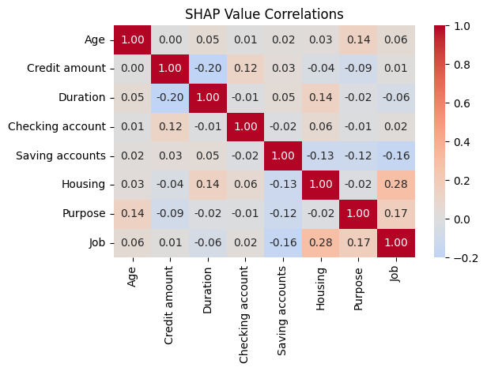

```python
# shap_values comes out as a list or array - extract the relevant output
sv = shap_values[0] if isinstance(shap_values, list) else shap_values

shap_df = pd.DataFrame(sv.squeeze(-1), columns=feature_names_out)
corr = shap_df.corr()
sns.heatmap(corr, annot=True, fmt=".2f", cmap="coolwarm", center=0)
plt.title("SHAP Value Correlations")
plt.tight_layout()
plt.show()
```

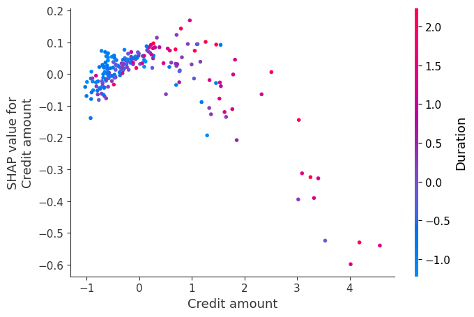

```python
background = torch.tensor(X_train_proc[:100], dtype=torch.float32)
explainer_shap = shap.GradientExplainer(model, background)
shap_values = explainer_shap.shap_values(torch.tensor(X_test_proc, dtype=torch.float32))

shap.dependence_plot(
    "Credit amount",
    sv,
    X_test_proc,
    feature_names=feature_names_out,
    interaction_index="Duration"
)
```

The negative correlation between `Duration` and `Credit amount` SHAP values requires careful interpretation. In terms of raw feature values, the dependence plot confirms that the two are positively correlated - large credit amounts tend to accompany long durations. However, in terms of SHAP attributions, the negative correlation indicates that the model treats them as partially compensating for each other: when one feature is penalized heavily, the other tends to be penalized less, suggesting the model evaluates their combined burden rather than each independently. The remaining interactions (**Job/Housing**, **Job/Purpose**) are weak and involve low-importance features, so they are unlikely to reflect meaningful decision logic.

Overall, the primary dependency worth noting is between `Duration` and `Credit amount`, which the model appears to evaluate jointly as a combined measure of financial commitment rather than two separate cost criteria.

### Q4

What is the nature of the criterion, gain, cost, non-monotonic?

```python
plt.figure()
shap.summary_plot(shap_values_2d, X_test_t.numpy(), feature_names=feature_names_out, plot_size=(10, 6), show=False, rng=42)
plt.title("SHAP Summary Plot")
plt.tight_layout()
plt.show()
```

[output not shown]

The nature of the criteria was determined using SHAP summary plots.

`Checking account` exhibits monotonic behavior for values 1–3, where increasing values correspond to increasingly favorable predictions. However, the value 0 deviates from this trend and is associated with the most positive contribution, breaking strict monotonicity. This indicates a special-case category effect, resulting in overall non-monotonic behavior with a structured pattern.

`Duration` is a clear cost criterion, with longer durations consistently leading to worse predictions, strongly supported by the SHAP value distribution.

`Credit amount` behaves primarily as a cost criterion, although noticeable non-monotonicity is present. Mid-range values are associated with more favorable outcomes, low values are ranging around the midpoint and very high values increase risk.

`Saving accounts` is not monotonic, middle values are slighlty negative, while both low and high values contribute positively.

`Housing` shows a gain-type tendency, where more stable housing situations correspond to better predictions, though the extreme value is highly separated from the rest while lower values remain mixed, showing only moderate monotonicity.

`Age` exhibits gain-type behavior, as higher values generally contribute positively to the prediction, visible in the SHAP value distribution.

`Purpose` demonstrates a monotonic trend, where higher encoded values are generally associated with less favorable outcomes, indicating an overall cost-type tendency.

`Job` is another monotonic criterion, where low values are negative, high values are positive and middle values are stuck around 0.

Overall, the model combines clearly monotonic cost and gain criteria (`Duration`, `Age`, `Purpose`, `Job`) with several criteria exhibiting structured but imperfect monotonicity, often influenced by specific category effects. This suggests that the decision process is largely consistent in direction but includes exceptions driven by particular feature values.

### Q5

Whether there are any preference thresholds? Are there any evaluations on criteria that are indifferent in terms of preferences?

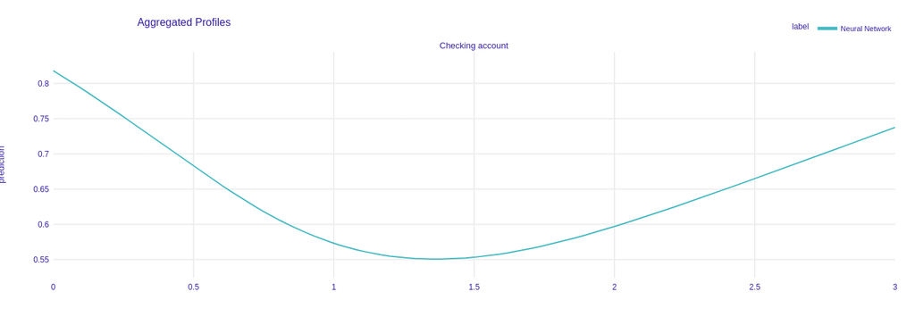

```python
explainer_dalex.model_profile(variables=["Checking account"]).plot()
```

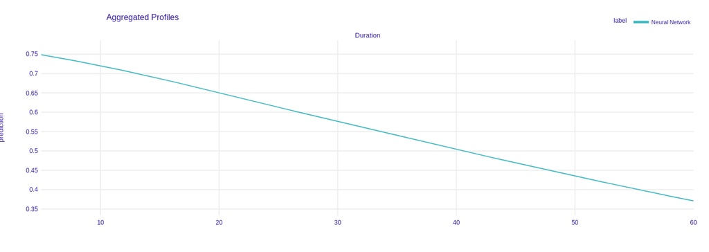

```python
explainer_dalex.model_profile(variables=["Duration"]).plot()
```

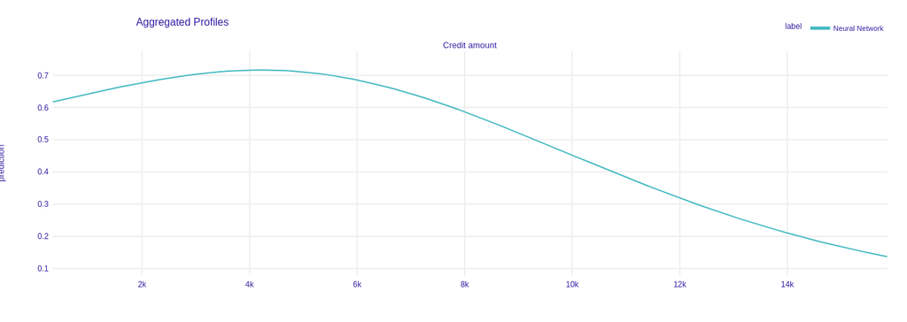

```python
explainer_dalex.model_profile(variables=["Credit amount"]).plot()
```

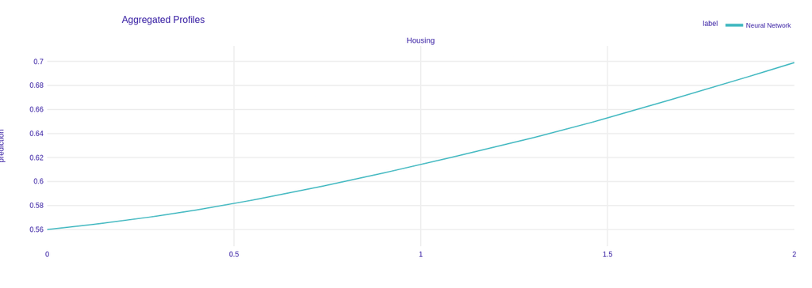

```python
explainer_dalex.model_profile(variables=["Housing"]).plot()
```

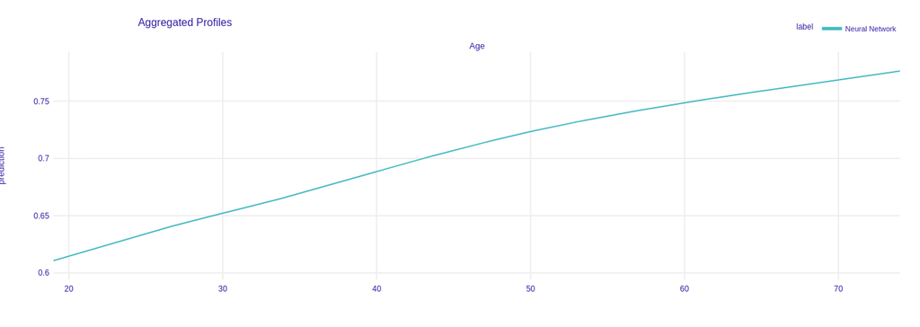

```python
explainer_dalex.model_profile(variables=["Age"]).plot()
```

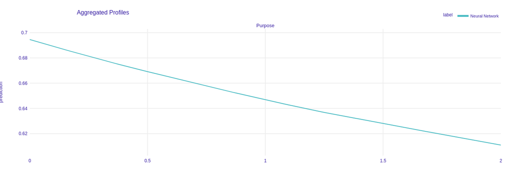

```python
explainer_dalex.model_profile(variables=["Purpose"]).plot()
```

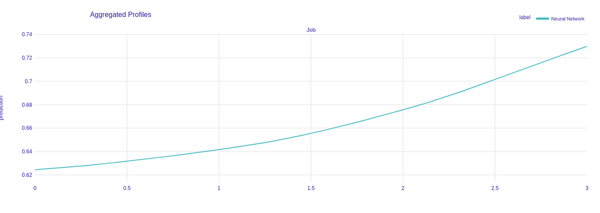

```python
explainer_dalex.model_profile(variables=["Job"]).plot()
```

**Thresholds**:

Unlike tree-based models, the neural network does not learn explicit decision thresholds - instead, its responses are smooth and continuous due to nonlinear activation functions. Empirical inflection points are visible in the partial dependence plots:

`Checking account` shows a notable inflection around the value of **1.4**, where the predicted contribution transitions from negative to positive, suggesting a soft threshold between unfavorable and favorable account status. Credit amount shows a change in direction around **4k**, where the effect shifts from favorable to increasingly negative, consistent with this value representing an informal risk boundary.

**Indifference zones**: Due to the smooth nature of the neural network, there are no flat regions or indifference zones in the strict sense. The model responds continuously across the entire range of all features, meaning that even small changes in feature values produce some change in the predicted outcome, unlike the discrete splits of tree-based models.

## Summary

**2.1 Explanation of Decisions**

Three alternatives were selected for analysis (samples 12, 71, and 131). For each, a SHAP waterfall plot was used to explain the individual prediction, identifying the most influential features driving the classification.

Minimum change analysis was performed both analytically and via sampling. The analytical approach used average SHAP values taken across the test set to estimate the required feature change needed to cross the decision boundary. The sampling approach used iterative perturbation of a single feature until the predicted class flipped.

In all three cases the analytical estimate overestimated the required change - `Credit amount` required a change of ~3.2 analytically vs. 0.73 empirically, `Duration` required ~0.26 vs. 0.09, and ~0.32 vs. 0.18 for sample 131. This consistent discrepancy reflects a fundamental limitation of population-averaged SHAP values for individual counterfactual reasoning: average attributions do not capture the specific feature interactions active for a given sample and underestimate the impact of a single variable modification. The sampling results are more reliable as they directly probe the model's decision boundary.

**2.2 Interpretation of the Model**

The neural network exhibits a clear and interpretable preference structure despite its black-box nature. Permutation feature importance and SHAP analysis consistently identify `Checking account`, `Credit amount`, `Duration`, and `Saving accounts` as the decisive criteria, while `Purpose`, `Housing`, `Job`, and `Age` have negligible influence.

The dominant criteria behave as cost criteria (`Duration`, `Credit amount`) or structured ordinal criteria (`Checking account`, `Saving accounts`), with the latter exhibiting non-monotonic behavior due to category-level effects at value 0. Age shows weak gain-type behavior. The primary interaction identified is between `Credit amount` and `Duration`, which the model appears to evaluate jointly as a combined measure of financial commitment.

Soft inflection points are visible in the partial dependence plots for `Checking account` (around 1.4) and `Credit amount` (around 4k), representing the only empirical thresholds in an otherwise smooth, continuous response surface. No indifference zones exist in the strict sense, unlike tree-based models.

Overall, the model reflects a conservative, risk-averse decision policy favoring applicants with strong account liquidity, low credit amounts, and short loan durations — consistent across both global interpretation techniques and individual counterfactual analyses.